# MTH6139 Time Series

Coursework 1

Andrew Samet

19/3/26

# Section 1: My Interests

What interest me is the trend in the results of football matches for my favourite team.

## Section 1.1: Why This Interest Me?

This interest me because I am big football fan, more specfically a big Man United fan. Despite the fact that it is very difficult to model football results well as they are so volatile, it is still a really interesting exercise to create time series and see how the model predicts Man United results for the future.

# Section 2: My Time Series

## Section 2.1: Time Series

This is a time series for Man United

[interactive chart not shown]

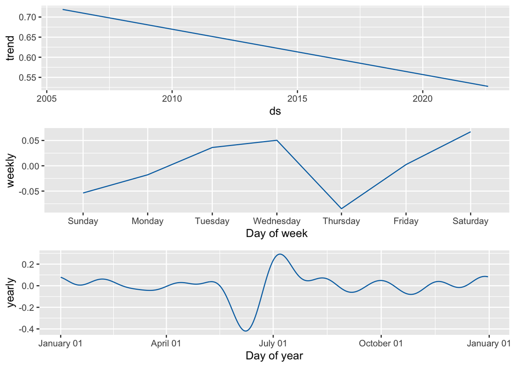

# Section 3: Another Time Series

This is another time series for Man City. I thought it would be interesting to compare the two, firstly, because Man City are big rivals of my team, Man United. Secondly, because Man City’s success has taken a very different path to that of Man United over the past 20 years.

## Section 3.1: Time Series

[interactive chart not shown]

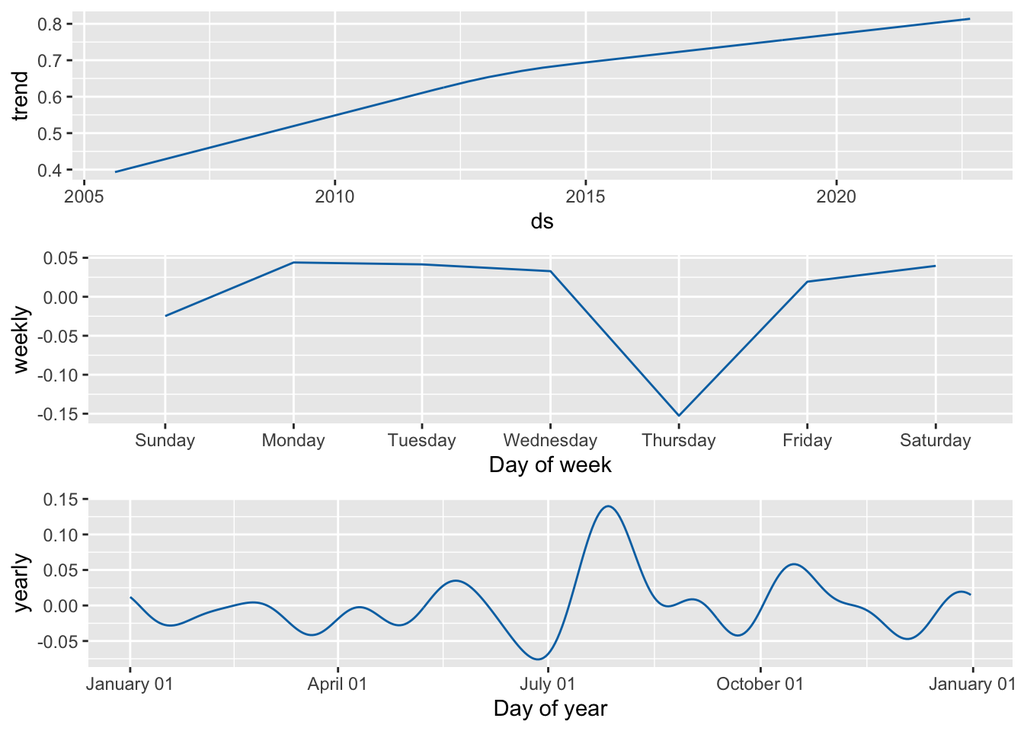

## Section 3.3: Observations

Again we see this dip on the weekly trend on Thursdays.

# Section 4: Summary

Perhaps the most striking thing to note is the gradual rise in success for Man City vs the gradual decline in success for Man United. You can see in the ‘trend’ plot, that Man City’s success has increased healthily over time, whereas Man United’s has decreased.